# Word Cloud - Donald Trump v.s. Barack Obama

ChiChen Lo

2018-04-09

# Summary

This R markdown demonstrate how to crawl corpus from public Facebook pages and use some basic NLP tools to clean the messy corpus. At last, two word cloud graphes are created for visualized comparison between the common words used in the posts of two famous polictics. ***

## Import all packages

Import all packages needed, including:  
- **worldcloud (including the requiring RColorBlew package)**: for wordcloud generation  
- **tm**: for most NLP manipulations  
- **Rfacebook**: for crawling facebook pages.

```r
library(RColorBrewer)
library(wordcloud)
library(tm)
library(Rfacebook)
```

## Donald Trump and Barack Obama’s pageID:

The faceook IDs: from https://findmyfbid.com/  
The Rfacebook.getPages can extract list of posts from public Facebook page. However, if the given n (number of posts inquery) is too large, the FB API may block the token and thus return an error.

```r
trumpID = '153080620724'
obamaID = '6815841748'
token = 'EAACEdEose0cBAFHNXFe3Q5hswPJ6wdaMzrZCrxkDO9nlV6gXS9C9wtcReDd…'

# get top 300 posts from Trump and Obama's facebook
trump_pages = getPage(trumpID, token, n=300)
```

```
## 25 posts 50 posts 75 posts 100 posts 125 posts 150 posts 175 posts 200 posts 225 posts 250 posts 275 posts 300 posts
```

```r
obama_pages = getPage(obamaID, token, n=300)
```

```
## 25 posts 50 posts 75 posts 100 posts 125 posts 150 posts 175 posts 200 posts 225 posts 250 posts 275 posts 300 posts
```

## corpus cleaning

Cleaning the crawled corpus, to make the later word cloud more concise and meaningful.

1. **remove emoji**: It surprise me that Donald Trump use a lot of emojis. Removing emojis is extremely difficult and frustrating task, since there are always expections in you regular expression that some emojis would be miss. After hours of struggle with emoji, I decide to remove every thing but English charators. This method may remove some contents other than emojis, but it is effective and remain the main texts.
2. **convert every charactor in to lower case**: Noted that if the charactors with no lower case are not remove in the last steps, the function would just fail.
3. **remove numbers**
4. **remove common english stopwords (from tm package)**: It is almost part of SOP of any NLP analysis. The stopword in any language could dominate the data and would corrupt the algorithms if they are not removed. It is the same case in world colud.
5. **emove punctuations**

```r
doc_O = Corpus(VectorSource(obama_pages$message))
doc_T = Corpus(VectorSource(trump_pages$message))

#remove emoji
regex = "[^\x01-\x7F]+"
 #(Only Trump use emoji)
doc_T = tm_map(doc_T, content_transformer(function(x) gsub(x, pattern=regex, replacement=' ')))

# convert charactors in to lower case
doc_O = tm_map(doc_O, content_transformer(tolower))
doc_T = tm_map(doc_T, content_transformer(tolower))

# remove numbers
doc_O = tm_map(doc_O, removeNumbers)
doc_T = tm_map(doc_T, removeNumbers)

# remove common english stopwords (from tm package)
doc_O = tm_map(doc_O, removeWords, stopwords("english"))
doc_T = tm_map(doc_T, removeWords, stopwords("english"))

# remove punctuations
doc_O = tm_map(doc_O, removePunctuation)
doc_T = tm_map(doc_T, removePunctuation)

m_O = as.matrix(TermDocumentMatrix(doc_O))
m_T = as.matrix(TermDocumentMatrix(doc_T))
```

## sort and make wordcloud

Count the frequncy of words and sort them according to it. Draw the word cloud graphes.

```r
v_O = sort(rowSums(m_O),decreasing = TRUE)
d_O = data.frame(word = names(v_O), freq = v_O)
head(d_O, 10)
```

```
##                word freq
## obama         obama   49
## climate     climate   49
## change       change   46
## court         court   44
## people       people   43
## supreme     supreme   41
## senate       senate   40
## president president   38
## ’s               ’s   37
## americans americans   37
```

```r
v_T = sort(rowSums(m_T),decreasing = TRUE)
d_T = data.frame(word = names(v_T), freq = v_T)
head(d_T, 10)
```

```
##                word freq
## will           will   70
## president president   67
## great         great   53
## meeting     meeting   50
## donald       donald   45
## schedule   schedule   44
## trump         trump   39
## american   american   33
## people       people   32
## country     country   32
```

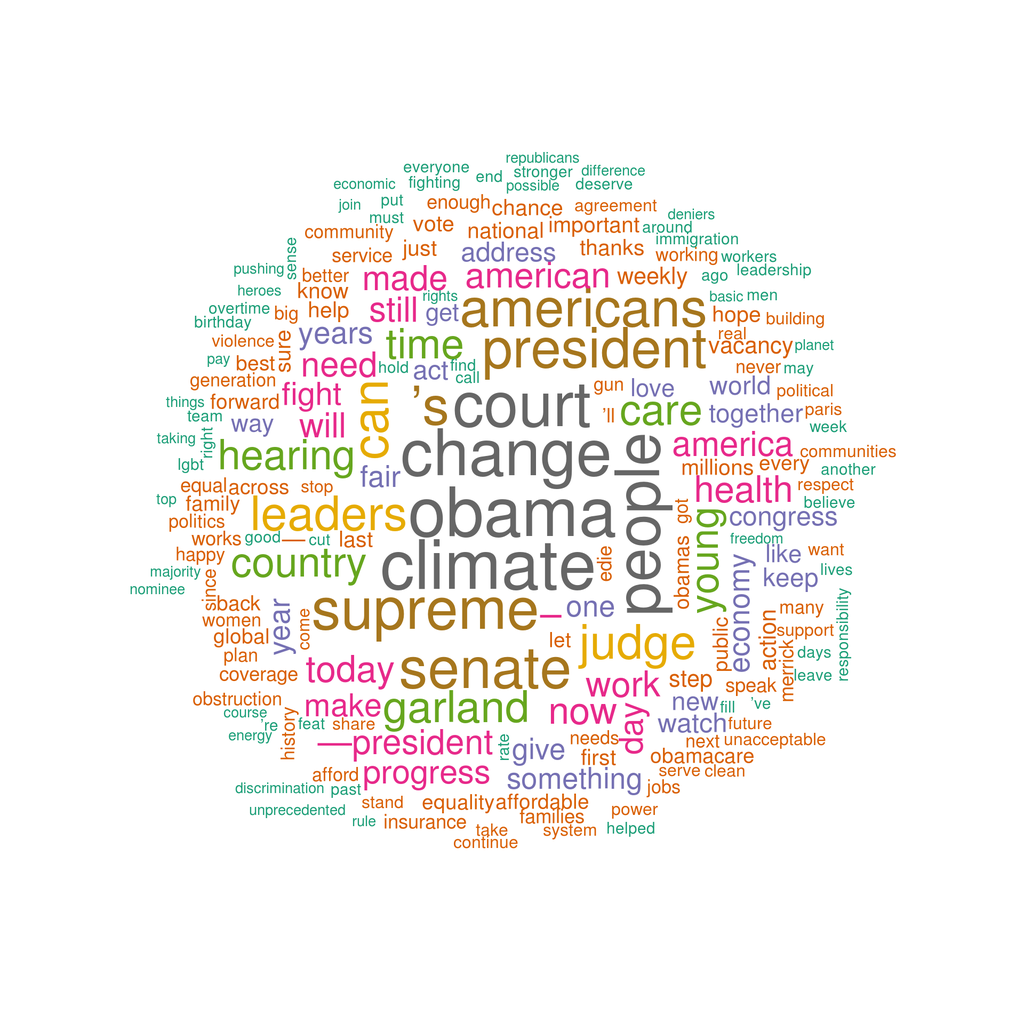

```r
wordcloud(words = d_O$word, freq = d_O$freq, min.freq = 1,
          max.words=200, random.order=FALSE, rot.per=0.1,
          colors=brewer.pal(8, "Dark2"))
```

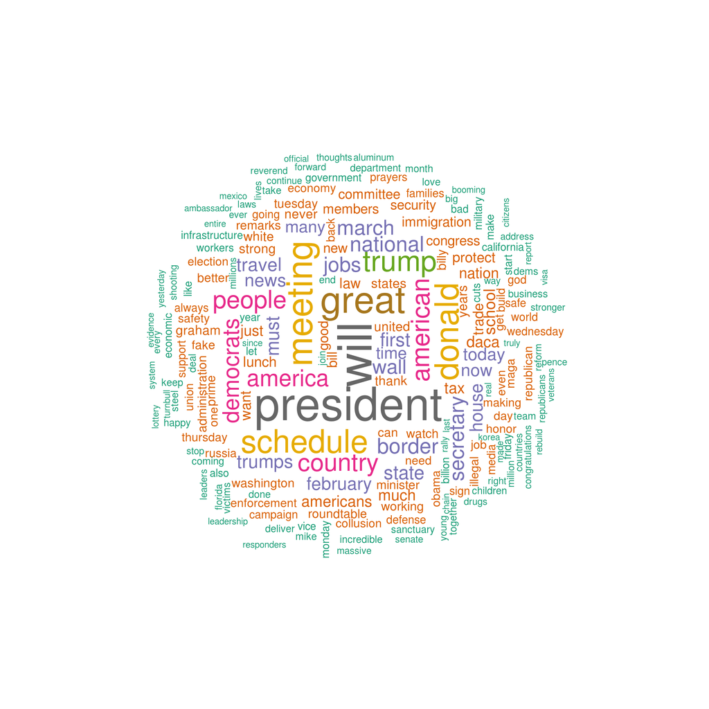

```r
wordcloud(words = d_T$word, freq = d_T$freq, min.freq = 1,
          max.words=200, random.order=FALSE, rot.per=0.35,
          colors=brewer.pal(8, "Dark2"))
```

## Analysis

Apparently, the two politics have their focus on different issues. Donald Trump focus on border and security issues of America and Americans, while Barack Obama concentrate on climate and congress issues. Also, Obama’s word cloud is bigger than Trump’s. Which indicate that the divisity of words that Obama used in his posts is larger than the conterpart of the Trump’s. It is a share result from many anaysis on Trump’s vocburary divisity, but I am surpriced that an corpus of only 300 post can still show this charactoristc.